Race and Threat Priming Nick Camp, Takuya Sawaoka, Erica Yoon ========================================================

# Study I: Replicating Weapons Bias

### Study I: Computing signal detection stats

For each subject, we calculate bias and sensitivity for BLACK and WHITE targets:

- Hit is defined as correctly identifying GUN after seeing GUN (accuracy rate for GUN trials)
- False Alarm is defined as incorrectly responding GUN after seeing TOOL (1-accuracy rate for TOOL trials)

```r
shortformWeapon$HitRateWhite=shortformWeapon$White_Gun
shortformWeapon$FARateWhite=1-shortformWeapon$White_Tool

shortformWeapon$HitRateBlack=shortformWeapon$Black_Gun
shortformWeapon$FARateBlack=1-shortformWeapon$Black_Tool

#If a S has a HR or FAR of 0 or 1, we can't calculate d prime. This adjusts extreme values by limiting these
#rates to (1/N) and (N-1)/N, where N is the number of trials used to calculate the HR or FAR.

NumTrials=aggregate(tool~workerid+race,data=trials1,length)[1,3];

shortformWeapon$HitRateWhite=recode(shortformWeapon$HitRateWhite,"0=(1/NumTrials);1=((NumTrials-1)/NumTrials)")
shortformWeapon$HitRateBlack=recode(shortformWeapon$HitRateBlack,"0=(1/NumTrials);1=((NumTrials-1)/NumTrials)")

shortformWeapon$FARateWhite=recode(shortformWeapon$FARateWhite,"0=(1/NumTrials);1=((NumTrials-1)/NumTrials)")
shortformWeapon$FARateBlack=recode(shortformWeapon$FARateBlack,"0=(1/NumTrials);1=((NumTrials-1)/NumTrials)")
```

These functions calculate sensitivity (dPrime), bias (beta), and criterion (c) using the HR and FAR.

```r
#D prime and bias functions from Pellier (2002)

#dprime: separation between the signal and the noise distribution, compared against the sd of the noise distribution. Higher dprime means that the signal can more readily be distinguished from the noise.

dprime <- function(hit,fa) {
  qnorm(hit) - qnorm(fa)
}

#beta: bias towards responding that the target is present, independent of whether the target actually is present. Higher bias means greater tendency towards responding 'present'.

beta <- function(hit,fa) {
  zhr <- qnorm(hit)
  zfar <- qnorm(fa)
  exp(-zhr*zhr/2+zfar*zfar/2)

}

#c is defined as the distance between the criterion and the neutral point, where the noise and signal distributions cross over. Negative values of c signify a bias toward responding yes, whereas positive values signify a bias toward the no response (thecriterion lies to the right of the neutral point).

criterion<-function(hit,fa) {
  zhr <- qnorm(hit)
  zfar <- qnorm(fa)
  -(zfar+zhr)/2
}
```

Now we compute sensitivity, bias, and criterion for Black and White primes.

```r
shortformWeapon$dPrimeWhite=dprime(shortformWeapon$HitRateWhite,shortformWeapon$FARateWhite)
shortformWeapon$dPrimeBlack=dprime(shortformWeapon$HitRateBlack,shortformWeapon$FARateBlack)

shortformWeapon$biasWhite=beta(shortformWeapon$HitRateWhite,shortformWeapon$FARateWhite)
shortformWeapon$biasBlack=beta(shortformWeapon$HitRateBlack,shortformWeapon$FARateBlack)

shortformWeapon$criterionWhite=criterion(shortformWeapon$HitRateWhite,shortformWeapon$FARateWhite)
shortformWeapon$criterionBlack=criterion(shortformWeapon$HitRateBlack,shortformWeapon$FARateBlack)
```

### Study I: Sensitivity by prime.

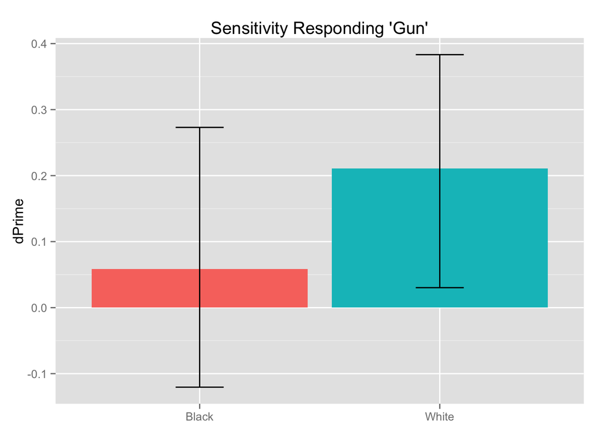

Stats in lmer:

```r
weapon.sensitivity <- lmer(dPrime ~ race + (1|workerid), data = dPrimesWeapons);summary(weapon.sensitivity)
```

```
## Linear mixed model fit by REML ['merModLmerTest']
## Formula: dPrime ~ race + (1 | workerid)
##    Data: dPrimesWeapons
##
## REML criterion at convergence: 316.1
##
## Scaled residuals:
##     Min      1Q  Median      3Q     Max
## -2.1082 -0.4091  0.0374  0.4711  2.4544
##
## Random effects:
##  Groups   Name        Variance Std.Dev.
##  workerid (Intercept) 0.444    0.666
##  Residual             0.233    0.482
## Number of obs: 144, groups: workerid, 72
##
## Fixed effects:
##             Estimate Std. Error      df t value Pr(>|t|)
## (Intercept)   0.0587     0.0970 99.3000    0.61    0.546
## raceWhite     0.1520     0.0804 71.0000    1.89    0.063 .
## ---
## Signif. codes:  0 '***' 0.001 '**' 0.01 '*' 0.05 '.' 0.1 ' ' 1
##
## Correlation of Fixed Effects:
##           (Intr)
## raceWhite -0.415
```

### Study I: Bias by prime.

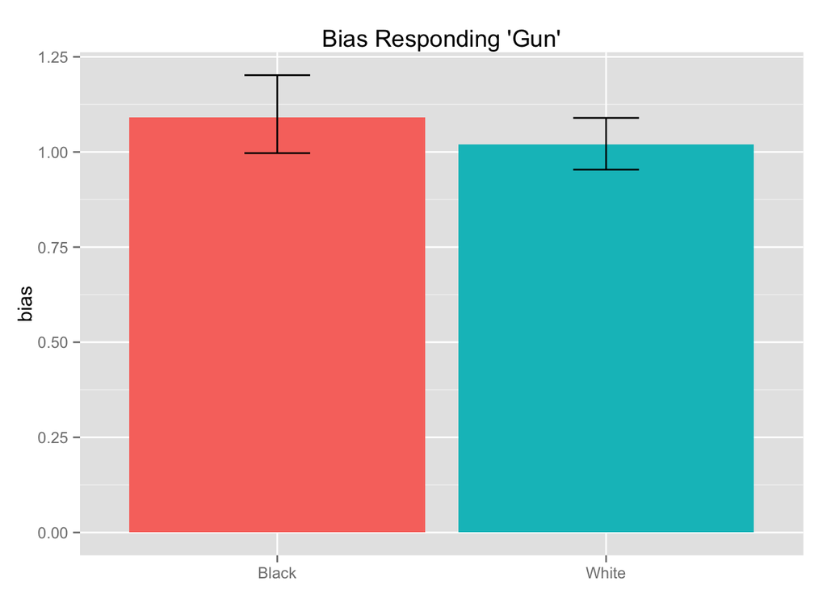

Stats in lmer:

```r
weapon.bias <- lmer(bias ~ race + (1|workerid), data = biasWeapon);summary(weapon.bias)
```

```
## Linear mixed model fit by REML ['merModLmerTest']
## Formula: bias ~ race + (1 | workerid)
##    Data: biasWeapon
##
## REML criterion at convergence: 145.7
##
## Scaled residuals:
##    Min     1Q Median     3Q    Max
## -1.919 -0.424 -0.156  0.200  7.003
##
## Random effects:
##  Groups   Name        Variance Std.Dev.
##  workerid (Intercept) 6.65e-18 2.58e-09
##  Residual             1.54e-01 3.92e-01
## Number of obs: 144, groups: workerid, 72
##
## Fixed effects:
##             Estimate Std. Error       df t value Pr(>|t|)
## (Intercept)   1.0912     0.0462 142.0000   23.61   <2e-16 ***
## raceWhite    -0.0715     0.0654 142.0000   -1.09     0.28
## ---
## Signif. codes:  0 '***' 0.001 '**' 0.01 '*' 0.05 '.' 0.1 ' ' 1
##
## Correlation of Fixed Effects:
##           (Intr)
## raceWhite -0.707
```

### Study I: Criterion by prime.

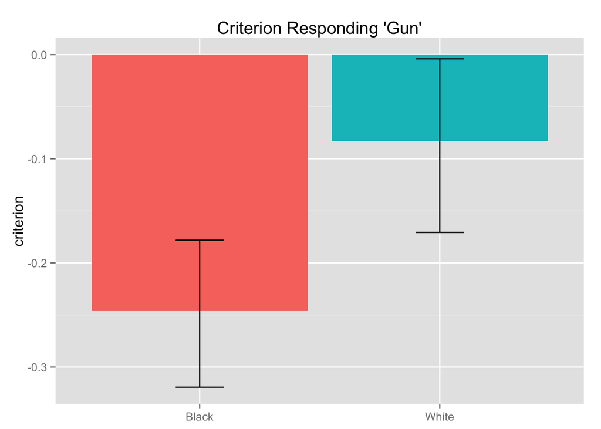

```r
weapon.criterion <- lmer(criterion ~ race + (1|workerid), data = criterionWeapon);summary(weapon.criterion)
```

```
## Linear mixed model fit by REML ['merModLmerTest']
## Formula: criterion ~ race + (1 | workerid)
##    Data: criterionWeapon
##
## REML criterion at convergence: 98
##
## Scaled residuals:
##     Min      1Q  Median      3Q     Max
## -3.1225 -0.5396 -0.0283  0.5713  3.0582
##
## Random effects:
##  Groups   Name        Variance Std.Dev.
##  workerid (Intercept) 0.00     0.000
##  Residual             0.11     0.332
## Number of obs: 144, groups: workerid, 72
##
## Fixed effects:
##             Estimate Std. Error       df t value Pr(>|t|)
## (Intercept)  -0.2464     0.0391 142.0000   -6.31  3.4e-09 ***
## raceWhite     0.1630     0.0553 142.0000    2.95   0.0037 **
## ---
## Signif. codes:  0 '***' 0.001 '**' 0.01 '*' 0.05 '.' 0.1 ' ' 1
##
## Correlation of Fixed Effects:
##           (Intr)
## raceWhite -0.707
```

```r
#Question: not sure why the workerid variance=0 in the Random Effects. Shouldn't the model be able to fit a participant level intercept across Black and White prime conditions?
```

Summary: When targets were primed with Black faces, participants were marginally LESS accurate in identifying weapons. There was no difference in bias, but a difference in criterion for responding “gun”: participants set a lower criterion after seeing Black faces.

# Study II: Race primes Snake identification

This study was the same design as Study I, only with Snakes substituted for Guns, and Ropes substituted for Tools.

Data setup is hidden, as it is the same as in Study I.

### Study II: Computing signal detection stats

For each subject, we calculate bias and sensitivity for BLACK and WHITE targets:

- Hit is defined as correctly identifying SNAKE after seeing SNAKE (accuracy rate for SNAKE trials)
- False Alarm is defined as incorrectly responding SNAKE after seeing ROPE (1-accuracy rate for ROPE trials)

*Omitted syntax below, since it’s so similar to Study I

Compute sensitivity, bias, and criterion for Black and White primes…

### Study II: Sensitivity by prime.

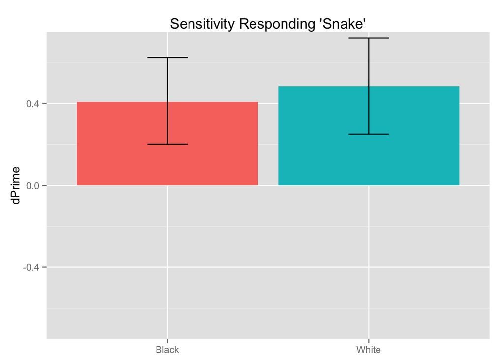

Stats in lmer:

```r
snake.sensitivity <- lmer(dPrime ~ race + (1|workerid), data = dPrimesSnakes);summary(snake.sensitivity)
```

```
## Linear mixed model fit by REML ['merModLmerTest']
## Formula: dPrime ~ race + (1 | workerid)
##    Data: dPrimesSnakes
##
## REML criterion at convergence: 341.1
##
## Scaled residuals:
##     Min      1Q  Median      3Q     Max
## -1.5586 -0.5453  0.0235  0.5216  1.9978
##
## Random effects:
##  Groups   Name        Variance Std.Dev.
##  workerid (Intercept) 0.783    0.885
##  Residual             0.209    0.457
## Number of obs: 144, groups: workerid, 72
##
## Fixed effects:
##             Estimate Std. Error      df t value Pr(>|t|)
## (Intercept)   0.4078     0.1173 87.5000    3.48   0.0008 ***
## raceWhite     0.0774     0.0762 71.0000    1.02   0.3133
## ---
## Signif. codes:  0 '***' 0.001 '**' 0.01 '*' 0.05 '.' 0.1 ' ' 1
##
## Correlation of Fixed Effects:
##           (Intr)
## raceWhite -0.325
```

### Study II: Bias by prime.

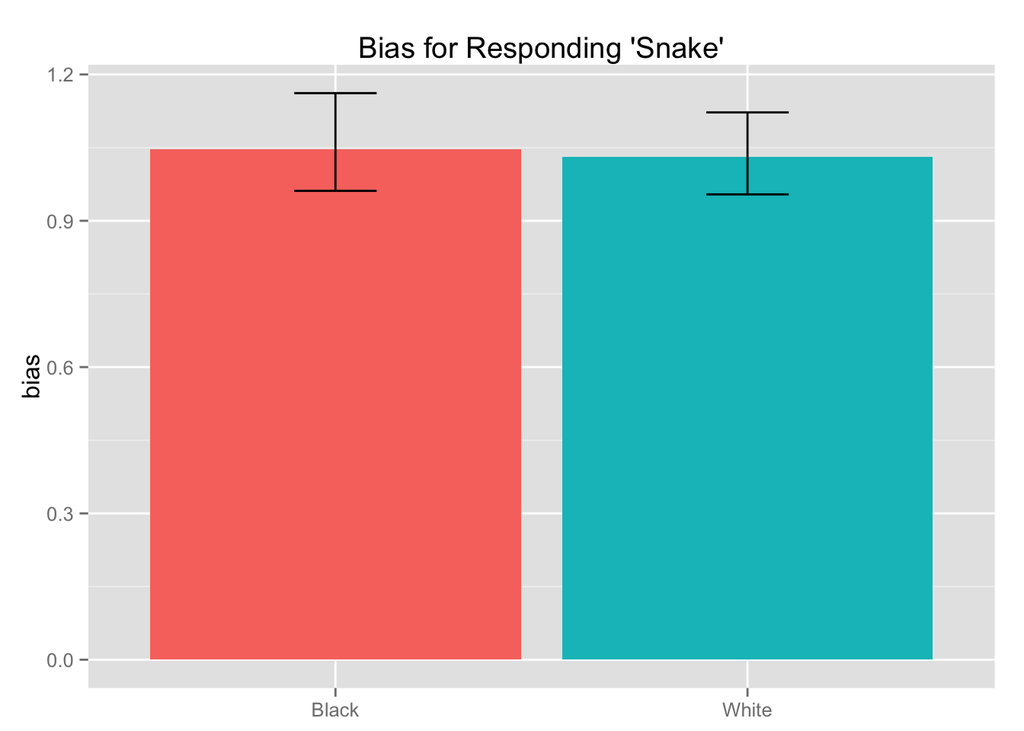

Stats in lmer:

```r
snake.bias <- lmer(bias ~ race + (1|workerid), data = biasSnake);summary(snake.bias)
```

```
## Linear mixed model fit by REML ['merModLmerTest']
## Formula: bias ~ race + (1 | workerid)
##    Data: biasSnake
##
## REML criterion at convergence: 157.7
##
## Scaled residuals:
##    Min     1Q Median     3Q    Max
## -1.490 -0.368 -0.103  0.107  6.460
##
## Random effects:
##  Groups   Name        Variance Std.Dev.
##  workerid (Intercept) 0.00648  0.0805
##  Residual             0.16097  0.4012
## Number of obs: 144, groups: workerid, 72
##
## Fixed effects:
##             Estimate Std. Error       df t value Pr(>|t|)
## (Intercept)   1.0471     0.0482 141.8000   21.71   <2e-16 ***
## raceWhite    -0.0168     0.0669  71.0000   -0.25      0.8
## ---
## Signif. codes:  0 '***' 0.001 '**' 0.01 '*' 0.05 '.' 0.1 ' ' 1
##
## Correlation of Fixed Effects:
##           (Intr)
## raceWhite -0.693
```

### Study II: Criterion by prime.

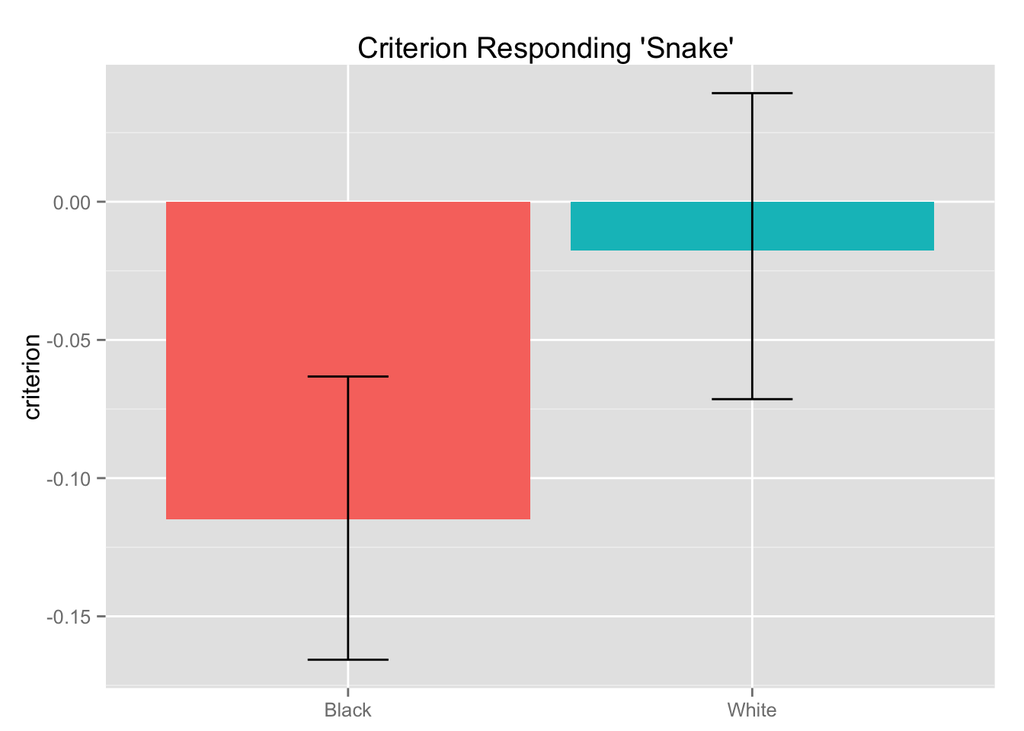

Stats with lmer:

```r
snake.criterion <- lmer(criterion ~ race + (1|workerid), data = criterionSnake);summary(snake.criterion)
```

```
## Linear mixed model fit by REML ['merModLmerTest']
## Formula: criterion ~ race + (1 | workerid)
##    Data: criterionSnake
##
## REML criterion at convergence: -2.1
##
## Scaled residuals:
##     Min      1Q  Median      3Q     Max
## -2.3741 -0.6457  0.0547  0.5928  2.8298
##
## Random effects:
##  Groups   Name        Variance Std.Dev.
##  workerid (Intercept) 0.00443  0.0666
##  Residual             0.05006  0.2237
## Number of obs: 144, groups: workerid, 72
##
## Fixed effects:
##             Estimate Std. Error       df t value Pr(>|t|)
## (Intercept)  -0.1149     0.0275 141.0000   -4.18  5.1e-05 ***
## raceWhite     0.0972     0.0373  71.0000    2.61    0.011 *
## ---
## Signif. codes:  0 '***' 0.001 '**' 0.01 '*' 0.05 '.' 0.1 ' ' 1
##
## Correlation of Fixed Effects:
##           (Intr)
## raceWhite -0.678
```

## Summary: When targets were primed with Black faces, participants set a lower criterion for responding “snake”. There were no differences in bias or sensitivity.

## Door/Window Study

### Study III: Computing signal detection stats

For each subject, we calculate bias and sensitivity for BLACK and WHITE targets:

- Hit is defined as correctly identifying door after seeing door (accuracy rate for door trials)
- False Alarm is defined as incorrectly responding door after seeing window (1-accuracy rate for window trials)

*Omitted syntax below, since it’s so similar to Study I

Compute sensitivity, bias, and criterion for Black and White primes…

### Study III: Sensitivity by prime.

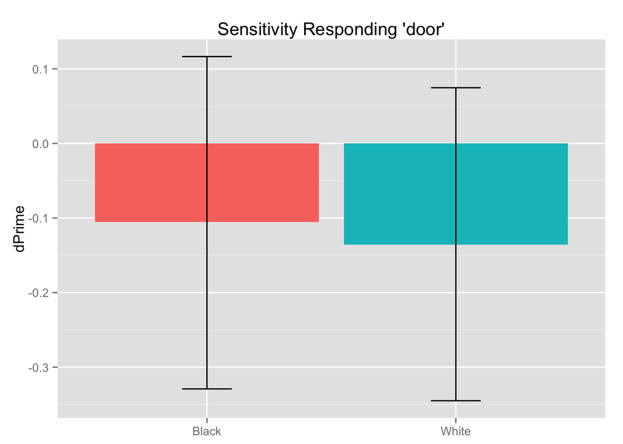

Stats in lmer:

```r
door.sensitivity <- lmer(dPrime ~ race + (1|workerid), data = dPrimesdoors);summary(door.sensitivity)
```

```
## Linear mixed model fit by REML ['merModLmerTest']
## Formula: dPrime ~ race + (1 | workerid)
##    Data: dPrimesdoors
##
## REML criterion at convergence: 336.3
##
## Scaled residuals:
##    Min     1Q Median     3Q    Max
## -2.539 -0.461  0.022  0.495  1.954
##
## Random effects:
##  Groups   Name        Variance Std.Dev.
##  workerid (Intercept) 0.691    0.831
##  Residual             0.194    0.440
## Number of obs: 148, groups: workerid, 74
##
## Fixed effects:
##             Estimate Std. Error      df t value Pr(>|t|)
## (Intercept)  -0.1056     0.1093 90.7000   -0.97     0.34
## raceWhite    -0.0298     0.0723 73.0000   -0.41     0.68
##
## Correlation of Fixed Effects:
##           (Intr)
## raceWhite -0.331
```

### Study III: Bias by prime.

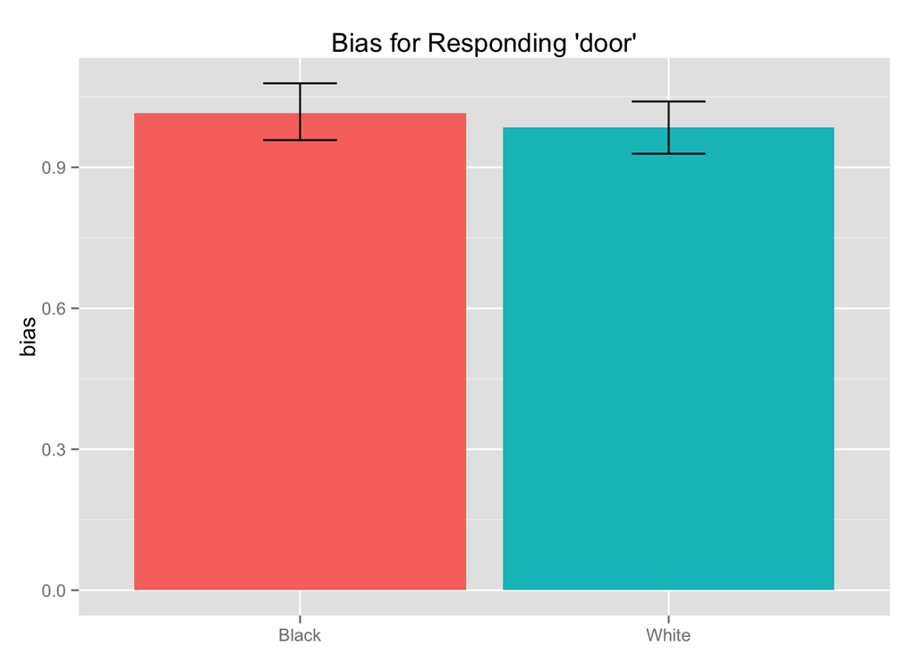

Stats in lmer:

```r
door.bias <- lmer(bias ~ race + (1|workerid), data = biasdoor);summary(door.bias)
```

```
## Linear mixed model fit by REML ['merModLmerTest']
## Formula: bias ~ race + (1 | workerid)
##    Data: biasdoor
##
## REML criterion at convergence: 15.9
##
## Scaled residuals:
##     Min      1Q  Median      3Q     Max
## -2.9311 -0.3994 -0.0743  0.2397  2.7709
##
## Random effects:
##  Groups   Name        Variance Std.Dev.
##  workerid (Intercept) 0.00633  0.0795
##  Residual             0.05554  0.2357
## Number of obs: 148, groups: workerid, 74
##
## Fixed effects:
##             Estimate Std. Error       df t value Pr(>|t|)
## (Intercept)   1.0161     0.0289 144.4000   35.14   <2e-16 ***
## raceWhite    -0.0304     0.0387  73.0000   -0.78     0.44
## ---
## Signif. codes:  0 '***' 0.001 '**' 0.01 '*' 0.05 '.' 0.1 ' ' 1
##
## Correlation of Fixed Effects:
##           (Intr)
## raceWhite -0.670
```

### Study III: Criterion by prime.

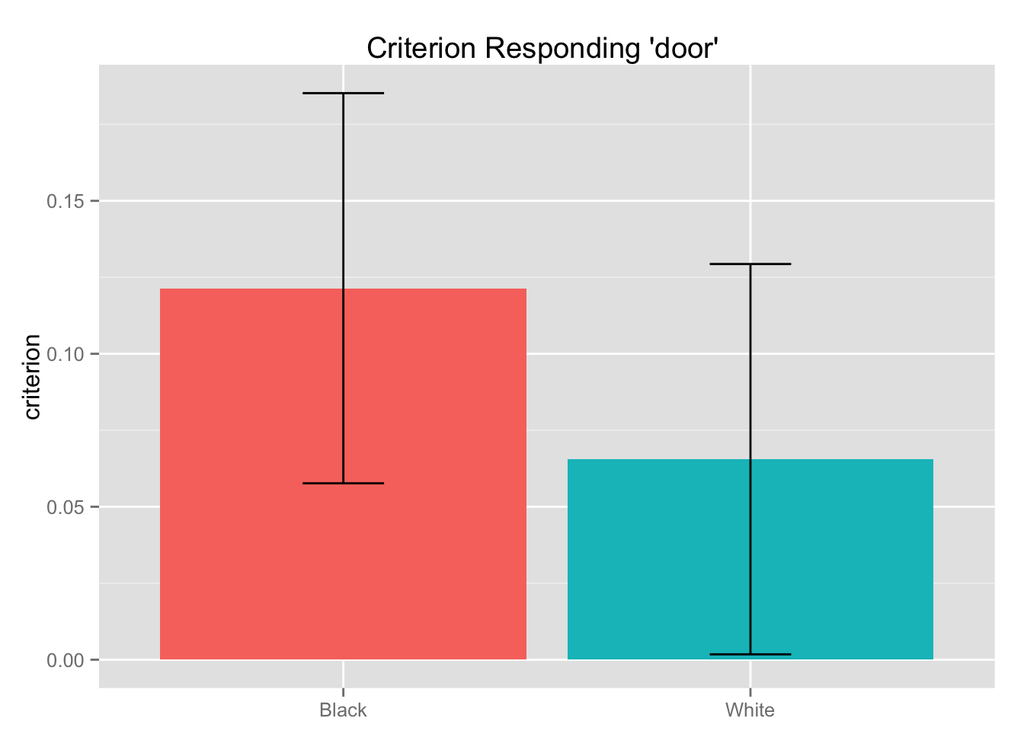

Stats with lmer:

```r
door.criterion <- lmer(criterion ~ race + (1|workerid), data = criteriondoor);summary(door.criterion)
```

```
## Linear mixed model fit by REML ['merModLmerTest']
## Formula: criterion ~ race + (1 | workerid)
##    Data: criteriondoor
##
## REML criterion at convergence: 47.3
##
## Scaled residuals:
##    Min     1Q Median     3Q    Max
## -3.345 -0.675 -0.023  0.572  2.528
##
## Random effects:
##  Groups   Name        Variance Std.Dev.
##  workerid (Intercept) 0.0198   0.141
##  Residual             0.0591   0.243
## Number of obs: 148, groups: workerid, 74
##
## Fixed effects:
##             Estimate Std. Error       df t value Pr(>|t|)
## (Intercept)   0.1213     0.0326 137.3000    3.72  0.00029 ***
## raceWhite    -0.0557     0.0400  73.0000   -1.39  0.16757
## ---
## Signif. codes:  0 '***' 0.001 '**' 0.01 '*' 0.05 '.' 0.1 ' ' 1
##
## Correlation of Fixed Effects:
##           (Intr)
## raceWhite -0.612
```

## Summary: There is no race priming effect for doors (versus windows) for sensitivity, bias, or criterion.

## Control Study: No Race Prime

In the control study, S (N=40) had 80 trials where gun or tool images were preceded by an image of static where the face had been in Studies I and II.

To help interpret the control condition, I’m graphing the results next to the Study I results.

### Control: Sensitivity.

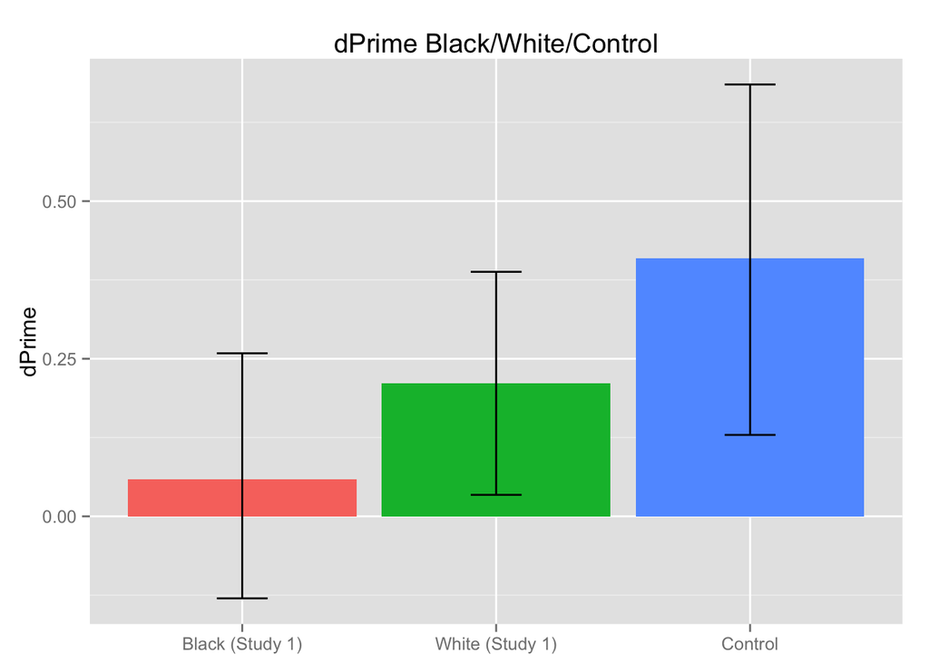

### Control: Bias.

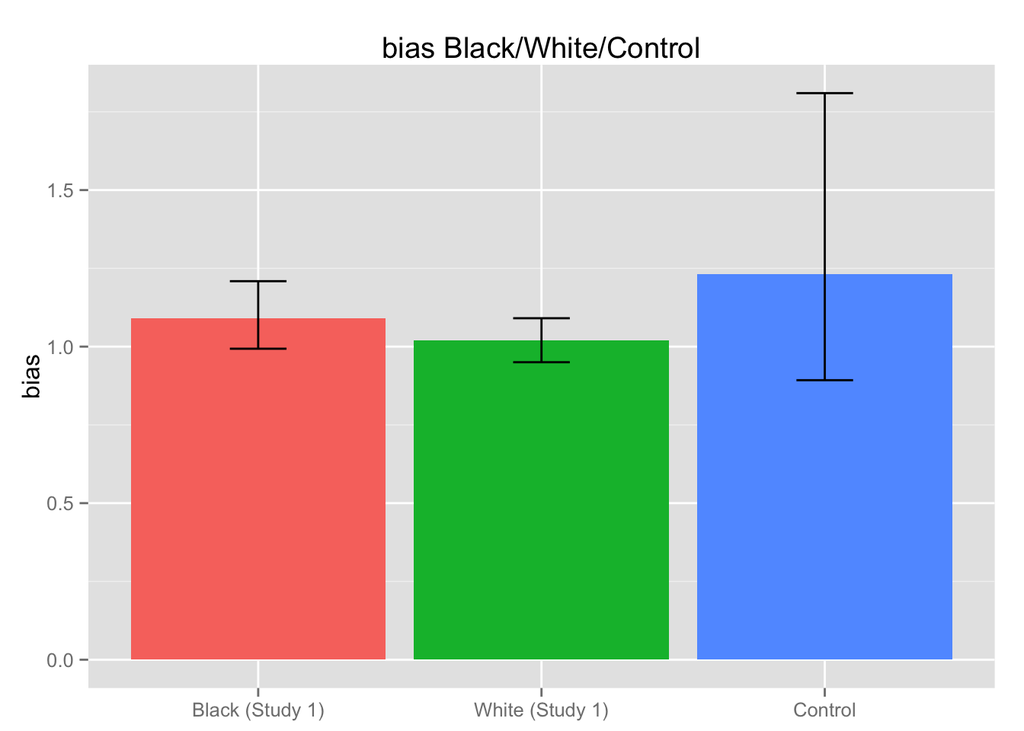

### Control: Criterion.

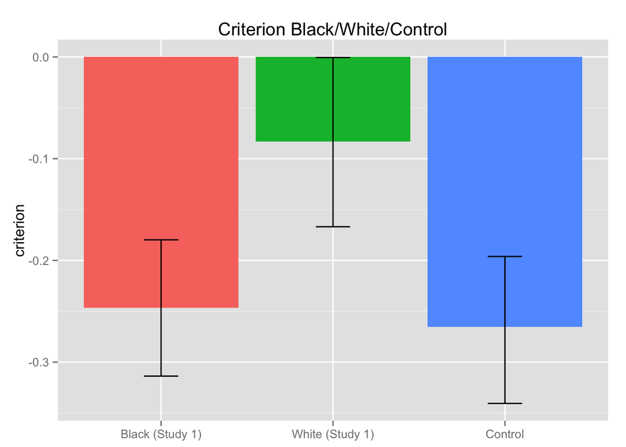

## Summary: When objects were primed with static images rather than faces, participants set a criterion that is equal to the the criterion for Black faces in Study I.

## However, participants were also more sensitive in the control study than they were in Study I.

# Summary Plots across all studies:

### Sensitivity

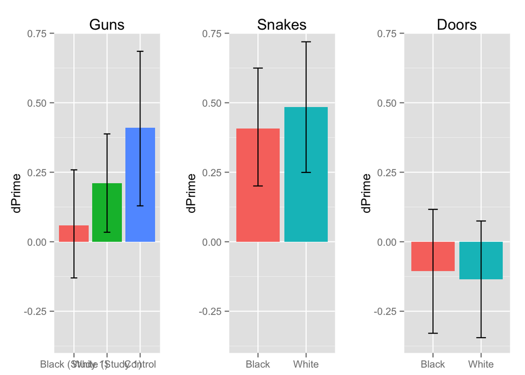

### Bias

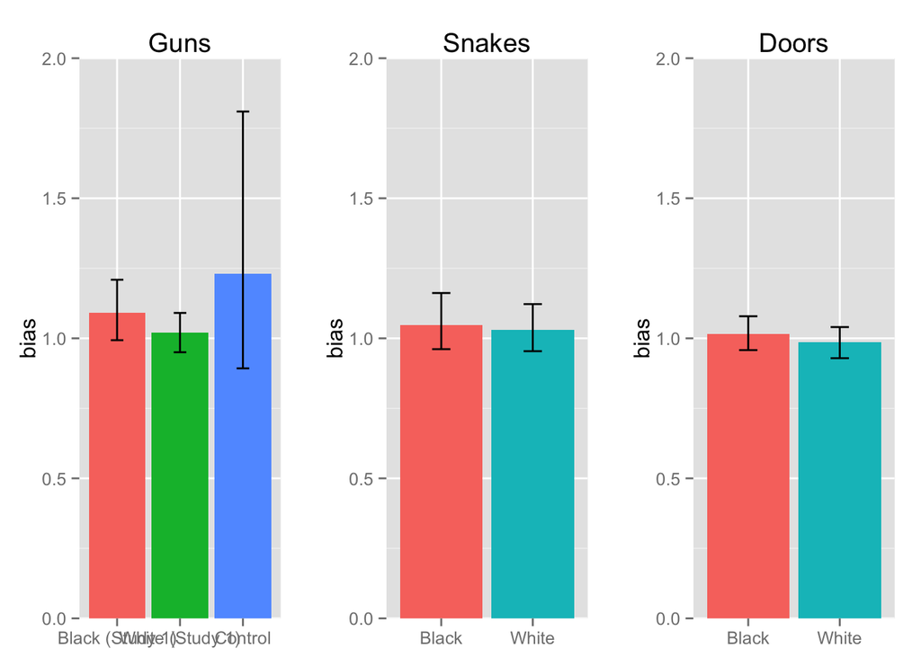

### Criterion

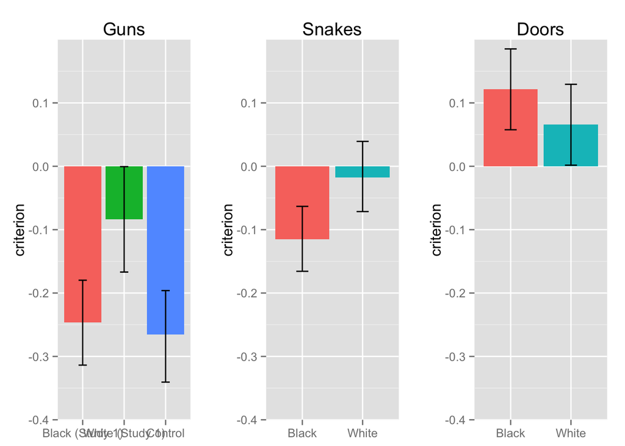